# STAA57 Final Project Report

Jason Wong

## Introduction

Students may build unhealthy habits such as stress eating or poor diet during their time in school in order to adapt to their environment whether due to the stress or the lack of time to prepare healthy meals. We’d like to explore whether there are consequences towards their physical well-being and if so, how severe are the consequences.

Furthermore, statistically speaking, more than half of Canadian university students self-diagnose themselves to feeling extreme anxiety due. Although most of these individuals tend to recover from these stressful events, being exposed to frequent periods of anxiety may increase the chances for other mental disorders to develop. We’d like to explore whether spending too much time in school may be a risk factor for mental disorders.

Lastly, some students may resort to substances such that alcohol or cannabis to help themselves cope with the stressful environment of university. Depending on the substance and the frequency of use, the consequences of substance abuse may stay with the user far past after they’ve finished their education. We’ve like to explore whether schooling has a correlation with the chances for addiction or usage in individuals.

## Data

The “Health Promotion Survey” data on CHASS will be used to explore physical health relations to education. The data is collected by observing adults all across Canada and surveying them about factors which may affect their physical well being. The data is collected in the ’90s, thus a lot of cultural norms was changed since. Thus when analyzing this data, we need to consider the fact that these trends may not project the current trends education may have on physical health but can provide us with a general idea. We plan on using the BMI to categorize individuals into weight groups such as; “Underweight, Healthy, Overweight, Obese”, and check if there’s a trend in physical well-being within different education groups.

## Analysis

### Physical Health

#### Data Exploration

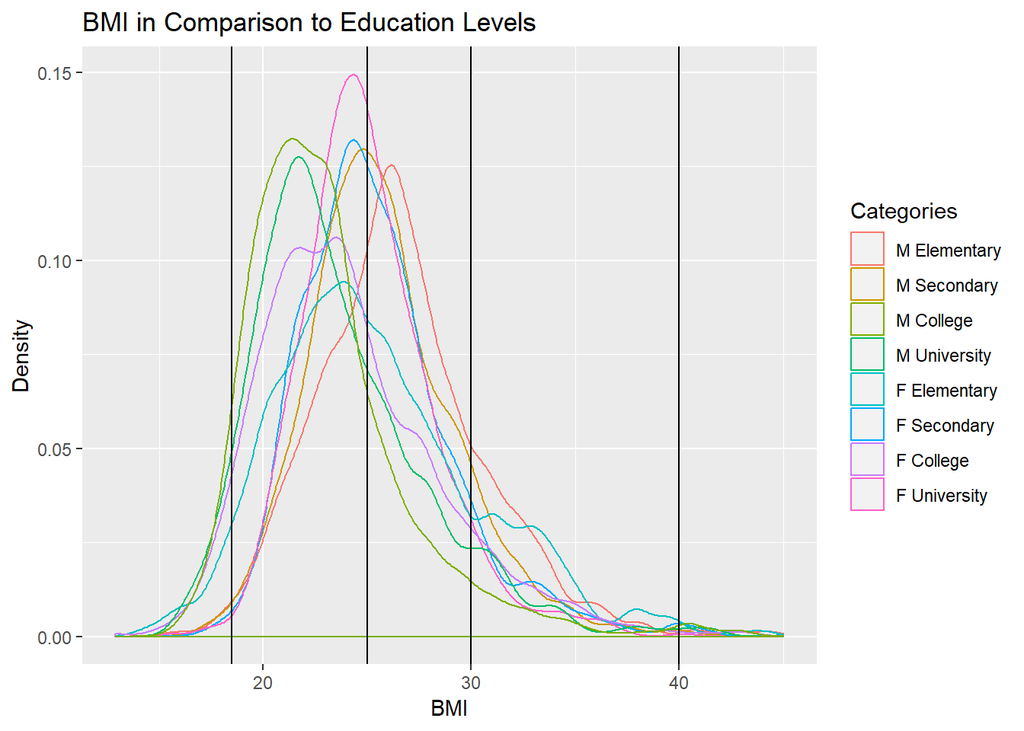

|  | Underweight | Healthy | Overweight | Obese |
| --- | --- | --- | --- | --- |
| Male Elementary | 0.0128 | 0.3408 | 0.4712 | 0.1752 |
| Male Secondary | 0.0082 | 0.4642 | 0.4206 | 0.1070 |
| Male College | 0.0070 | 0.5020 | 0.3934 | 0.0976 |
| Male University | 0.0060 | 0.5498 | 0.3808 | 0.0634 |
| Female Elementary | 0.0448 | 0.4906 | 0.2922 | 0.1724 |
| Female Secondary | 0.0540 | 0.6008 | 0.2454 | 0.0998 |
| Female College | 0.0620 | 0.6488 | 0.2074 | 0.0818 |
| Female University | 0.0564 | 0.7356 | 0.1554 | 0.0526 |

From exploring the data, we can is that although the density plot does not show a clear correlation between education and physical well-being, calculating the ratios of individuals in each category and plotting the results as a barplot reveals a slight tren. We noticed that as the groups education increases, the less amount of non-healthy BMI scores exist. Thus at the university level of education, we see the most amount of healthy individuals in both gender categories.

#### Data Modeling/ Inference

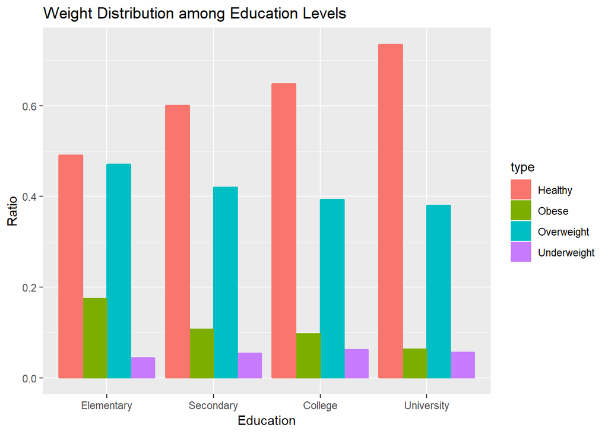

| term | estimate | std.error | statistic | p.value |
| --- | --- | --- | --- | --- |
| (Intercept) | 0.1931286 | 0.1120319 | 1.7238712 | 0.0975913 |
| numberic_educ | 0.0278757 | 0.0087217 | 3.1961434 | 0.0038767 |
| typeObese | 0.0903286 | 0.1584370 | 0.5701228 | 0.5738934 |
| typeOverweight | 0.3045286 | 0.1584370 | 1.9220794 | 0.0665451 |
| typeUnderweight | -0.1673714 | 0.1584370 | -1.0563908 | 0.3013080 |
| numberic_educ:typeObese | -0.0420543 | 0.0123343 | -3.4095378 | 0.0023029 |
| numberic_educ:typeOverweight | -0.0420243 | 0.0123343 | -3.4071056 | 0.0023168 |
| numberic_educ:typeUnderweight | -0.0274243 | 0.0123343 | -2.2234152 | 0.0358574 |

|  | Underweight | Healthy | Overweight | Obese |
| --- | --- | --- | --- | --- |
| Masters | 0.0369224 | 0.6906647 | 0.2433512 | 0.0308582 |
| PhD | 0.0419108 | 0.8565815 | 0.1551254 | -0.0512224 |

Since we assume for there to be a relationship between education and BMI score, we’ve attempted to fit a model for each weight catergory and used it to predict the ratios of individual who may have Masters and PhD level of education. Since education is a categorical value, we defined education as the amount of years spent in schooling to more accurately compute a proper model. Our predictions alined with our earlier hypothesis, however our predicitons is prone to yield negative values and values over 1 as education increases as our data closely resembles a linear model.

## Appendix

### References

- Attitudes and behaviours regarding the non-medical use of drugs
- http://sda.chass.utoronto.ca/sdaweb/nac/g0000036/doc/g036.htm
- Canadian alcohol and drug use monitoring survey
- http://sda.chass.utoronto.ca/sdaweb/dli2/cadums/cadums08/doc/cadu.htm
- Canadian Community Health Survey 2012
- http://sda.chass.utoronto.ca/cgi-bin/sda/hsda?harcsda3+cchs2012mh
- Health Promotion Survey
- http://sda.chass.utoronto.ca/cgi-bin/sda/hsda?harcsda+hps90